# Sparcc Simulation 1

Anonymous

02/03/2025

```r
rm(list = ls())
library(dplyr)
library(tidyverse)
library(ggplot2)
library(stringr)
library(ggh4x)
library(scales)
library(ggthemes)
library(kableExtra)
```

## Simulation Setup

The goal of this program is to evaluate the performance of the semiparametric efficient estimator $\widehat{\pmb{\beta}}_{sp}$ using simulations in the following setting:

- $Z \sim \textrm{Bernoulli}(0.5)$,
- $X|Z \sim \textrm{beta}(\alpha_1 + \alpha_2 Z, \alpha_3 + \alpha_4 Z)$,
- $C|Z \sim \textrm{beta}(\gamma_1 + \gamma_2 Z, \gamma_3 + \gamma_4 Z)$,
- $Y|X,Z \sim N(\beta_0 + \beta_1X + \beta_2Z, \sigma^2)$.

In these simulations, we vary the censoring probability $q=\textrm{P}(X>C)$.

We also vary which how nuisance distributions are modeled: $X|Z$ (or $C|Z$) correctly specified as beta conditional on $Z$ with estimated parameters $\pmb{\alpha}, \pmb{\gamma}$, $X|Z$ (or $C|Z$) incorrectly specified as marginal beta, or both $X|Z$ and $C|Z$ nonparametrically estimated.

For each simulation, we generate a data set of size $n$ then compute the complete case estimator $\widehat{\pmb{\beta}}_{cc}$, the oracle estimator $\widehat{\pmb{\beta}}_{or}$, the parametric MLE $\widehat{\pmb{\beta}}_{ml}$, and the semiparametric efficient estimator $\widehat{\pmb{\beta}}_{sp}$.

```r
# true beta
B.true <- c(1, 10, 2, log(1))

# load simulation results from each of 10 clusters
sim.out.list <- lapply(
  X = 0:9,
  FUN = function(clust) {
    cbind(clust,
          read.csv(paste0(
            "sim1_data/sd",
            clust, ".csv")))
  })

# combine simulation results into 1 data frame
sim.out <- bind_rows(sim.out.list)

colnames(sim.out) <- gsub(".B", ".", colnames(sim.out))
colnames(sim.out) <- gsub("B2", "trueB2", colnames(sim.out))

# make long data frame
sim.out.long <- sim.out %>%
  pivot_longer(cols = starts_with(c("B", "V")),
               names_to = "method.param",
               values_to = "estimate") %>%
  mutate(name = factor(str_sub(method.param, 1, 1)),
         method = factor(str_sub(method.param, 3, 4),
                         levels = c("sp", "ml", "cc", "or"),
                         labels = c("Semipar", "MLE", "CC", "Oracle")),
         nuis.x = factor(str_sub(str_sub(
           gsub("[.]", "", method.param), 4, -2), 1, 1),
           levels = c("", "1", "0",  "2"),
           labels = c("-", "Correct", "Incorrect", "Nonpar")),
         nuis.c = factor(str_sub(str_sub(
           gsub("[.]", "", method.param), 4, -2), 2, 2),
           levels = c("", "1", "0",  "2"),
           labels = c("-", "Correct", "Incorrect", "Nonpar")),
         param = factor(str_sub(method.param, -1, -1)),
         B.true = B.true[param]) %>%
  dplyr::select(-c(method.param)) %>%
  group_by(clust, n, q, name, method, nuis.x, nuis.c, param) %>%
  mutate(id = row_number()) %>%
  pivot_wider(names_from = name,
              values_from = estimate,
              id_cols = c(clust, n, q, method, nuis.x, nuis.c,
                          param, B.true, id)) %>%
  mutate(B = ifelse(abs(B - B.true) > 10, NA, B),
         ci.lower = B - qnorm(0.975) * V,
         ci.upper = B + qnorm(0.975) * V,
         ci.cov = B.true >= ci.lower & B.true <= ci.upper)
```

## Simulation Results

#### Errors in Simulations

We first look at which simulation settings lead to errors.

```r
# check for simulations with errors
sim.out.long %>%
  filter(param == 1) %>%
  group_by(q, n, method, nuis.x, nuis.c) %>%
  summarize(n.error = sum(is.na(B)),
            prop.error = mean(is.na(B))) %>%
  filter(prop.error > 0) %>%
  kable(digits = 3) %>%
  kable_styling("striped")
```

q

n

method

nuis.x

nuis.c

n.error

prop.error

0.4

200

Semipar

Correct

Correct

1

0.001

0.4

200

Semipar

Correct

Incorrect

1

0.001

0.4

200

Semipar

Incorrect

Correct

1

0.001

0.4

200

Semipar

Incorrect

Incorrect

1

0.001

0.4

200

Semipar

Nonpar

Nonpar

1

0.001

0.4

200

MLE

Correct

1

0.001

0.4

200

MLE

Incorrect

1

0.001

0.4

200

MLE

Nonpar

1

0.001

0.4

200

CC

1

0.001

0.4

200

Oracle

1

0.001

0.4

8000

Semipar

Correct

Correct

1

0.001

0.4

8000

Semipar

Correct

Incorrect

1

0.001

0.4

8000

Semipar

Incorrect

Correct

1

0.001

0.4

8000

Semipar

Incorrect

Incorrect

1

0.001

0.4

8000

Semipar

Nonpar

Nonpar

1

0.001

0.4

8000

MLE

Correct

1

0.001

0.4

8000

MLE

Incorrect

1

0.001

0.4

8000

MLE

Nonpar

1

0.001

0.4

8000

CC

1

0.001

0.4

8000

Oracle

1

0.001

0.8

200

Semipar

Correct

Correct

16

0.016

0.8

200

Semipar

Correct

Incorrect

16

0.016

0.8

200

Semipar

Incorrect

Correct

18

0.018

0.8

200

Semipar

Incorrect

Incorrect

17

0.017

0.8

200

Semipar

Nonpar

Nonpar

16

0.016

0.8

200

MLE

Correct

89

0.089

0.8

200

MLE

Incorrect

350

0.350

0.8

200

MLE

Nonpar

147

0.147

0.8

200

CC

16

0.016

0.8

200

Oracle

88

0.088

0.8

800

MLE

Incorrect

208

0.208

0.8

800

MLE

Nonpar

17

0.017

0.8

8000

MLE

Incorrect

3

0.003

#### Table of Results

```r
# table with simulation results
make.table <- function(param., n., format = "html") {

  tbl1 <- sim.out.long %>%
    filter(param == param.,
           n == n.) %>%
    group_by(q, method, nuis.x, nuis.c) %>%
    summarise(v1_Bias = 10*mean(B - B.true, na.rm = T),
              v2_ESE = 10*sd(B, na.rm = T),
              v3_ASE = 10*mean(V, na.rm = T),
              v4_Cov = 100*mean(ci.cov, na.rm = T)) %>%
  gather(key, value, v1_Bias:v4_Cov) %>%
  unite(Group, q, key) %>%
  spread(Group, value)

  kbl1 <- setNames(tbl1, c("Method", "X|Z", "C|Z",
                   sub(".+_", "", tail(names(tbl1), -3)))) %>%
    kable(digits = c(0, 0, 0,
                     2, 2, 2, 1,
                     2, 2, 2, 1),
          format = format,
          align = "lccrrrrrrrr",
          booktabs = T) %>%
    kable_styling("striped") %>%
    row_spec(row = 0, bold = TRUE)
    add_header_above(c(" " = 3,
                       "q = 0.4" = 4,
                       "q = 0.8" = 4))

  return(kbl1)

}
```

```r
print("param = 2, n = 200"); make.table(param. = 2, n. = 200)
```

```
## [1] "param = 2, n = 200"
```

Method

X|Z

C|Z

Bias

ESE

ASE

Cov

Bias

ESE

ASE

Cov

Semipar

Correct

Correct

-0.18

5.28

5.08

94.2

1.18

10.44

9.23

90.0

Semipar

Correct

Incorrect

-0.18

5.28

5.08

94.2

1.18

10.50

9.19

89.7

Semipar

Incorrect

Correct

-0.21

5.32

5.12

94.1

1.49

12.00

10.67

86.4

Semipar

Incorrect

Incorrect

-0.21

5.32

5.11

94.1

1.45

11.94

10.56

86.4

Semipar

Nonpar

Nonpar

-0.21

5.31

5.10

94.0

0.64

10.92

9.56

88.4

MLE

Correct

0.14

4.22

4.09

94.3

0.38

8.95

9.40

96.9

MLE

Incorrect

-4.69

4.25

4.19

79.9

-15.32

9.95

10.50

75.5

MLE

Nonpar

-1.65

5.02

5.30

93.0

-5.60

11.83

14.39

82.0

CC

-0.23

5.37

5.16

93.8

-0.71

12.37

10.87

90.5

Oracle

-0.10

3.37

3.24

93.4

-0.13

3.30

3.25

95.4

```r
print("param = 2, n = 800"); make.table(param. = 2, n. = 800)
```

```
## [1] "param = 2, n = 800"
```

Method

X|Z

C|Z

Bias

ESE

ASE

Cov

Bias

ESE

ASE

Cov

Semipar

Correct

Correct

0.12

2.50

2.56

95.8

0.52

4.68

4.61

93.8

Semipar

Correct

Incorrect

0.12

2.50

2.55

95.9

0.51

4.70

4.62

93.9

Semipar

Incorrect

Correct

0.08

2.52

2.58

96.2

0.32

5.64

5.30

92.3

Semipar

Incorrect

Incorrect

0.09

2.52

2.57

96.1

0.29

5.62

5.28

92.3

Semipar

Nonpar

Nonpar

0.08

2.51

2.56

95.9

0.19

5.03

4.85

93.2

MLE

Correct

0.23

2.03

2.03

94.6

0.30

4.03

3.98

95.9

MLE

Incorrect

-4.47

2.08

2.07

42.6

-16.92

4.43

5.43

1.9

MLE

Nonpar

-0.77

2.44

3.67

94.9

-4.54

7.22

8.85

84.0

CC

0.09

2.54

2.59

96.0

0.12

5.67

5.52

93.8

Oracle

0.04

1.65

1.63

94.6

0.00

1.69

1.63

93.2

```r
print("param = 2, n = 8000"); make.table(param. = 2, n = 8000)
```

```
## [1] "param = 2, n = 8000"
```

Method

X|Z

C|Z

Bias

ESE

ASE

Cov

Bias

ESE

ASE

Cov

Semipar

Correct

Correct

0.08

0.81

0.81

94.6

0.15

1.44

1.46

94.9

Semipar

Correct

Incorrect

0.09

0.81

0.81

94.6

0.15

1.44

1.46

94.8

Semipar

Incorrect

Correct

0.05

0.82

0.82

94.8

-0.44

1.64

1.66

93.7

Semipar

Incorrect

Incorrect

0.06

0.82

0.82

94.5

-0.46

1.64

1.66

93.7

Semipar

Nonpar

Nonpar

0.05

0.82

0.81

94.9

-0.45

1.58

1.52

92.8

MLE

Correct

0.17

0.62

0.64

94.8

0.21

1.24

1.21

93.6

MLE

Incorrect

-4.49

0.63

0.66

0.0

-17.84

1.71

1.76

0.0

MLE

Nonpar

-0.40

0.84

1.06

93.2

-2.21

2.79

4.14

88.8

CC

0.06

0.83

0.82

94.8

-0.03

1.74

1.76

95.1

Oracle

0.03

0.51

0.52

95.2

0.00

0.52

0.52

94.6

```r
# table with X coefficient only and n = 8000
t2 <- make.table(param. = 2, n. = 8000, format = "latex")
```

```r
# table and all parameters
make.table.allparam <- function(n., format = "html") {

  tbl1 <- sim.out.long %>%
    filter(n == n.) %>%
    mutate(Param = ifelse(param == 1, "$\\beta_1$",
                   ifelse(param == 2, "$\\beta_2$",
                   ifelse(param == 3, "$\\beta_3$",
                          "$\\log\\sigma^2$")))) %>%
    group_by(q, Param, method, nuis.x, nuis.c) %>%
    summarise(v1_Bias = 10*mean(B - B.true, na.rm = T),
              v2_ESE = 10*sd(B, na.rm = T),
              v3_ASE = 10*mean(V, na.rm = T),
              v4_Cov = 100*mean(ci.cov, na.rm = T)) %>%
  gather(key, value, v1_Bias:v4_Cov) %>%
  unite(Group, q, key) %>%
  spread(Group, value)

  kbl1 <- setNames(tbl1, c("Param", "Method", "X|Z", "C|Z",
                   sub(".+_", "", tail(names(tbl1), -4)))) %>%
    kable(digits = c(0, 0, 0, 0,
                     2, 2, 2, 1,
                     2, 2, 2, 1),
          format = format,
          align = "ccccrrrrrrrr",
          booktabs = T) %>%
    kable_styling("striped") %>%
    row_spec(row = 0, bold = TRUE) %>%
    add_header_above(c(" " = 4,
                       "q = 0.4" = 4,
                       "q = 0.8" = 4))

  return(kbl1)

}
```

```r
print("n = 200"); make.table.allparam(n. = 200)
```

```
## [1] "n = 200"
```

q = 0.4

q = 0.8

Param

Method

X|Z

C|Z

Bias

ESE

ASE

Cov

Bias

ESE

ASE

Cov

$\beta_1$

Semipar

Correct

Correct

0.17

2.96

2.92

94.3

-0.34

5.03

4.31

92.3

$\beta_1$

Semipar

Correct

Incorrect

0.17

2.96

2.93

94.3

-0.28

4.84

4.31

92.4

$\beta_1$

Semipar

Incorrect

Correct

0.18

2.97

2.94

94.4

-0.46

5.04

4.69

91.3

$\beta_1$

Semipar

Incorrect

Incorrect

0.18

2.97

2.94

94.3

-0.44

5.03

4.64

91.3

$\beta_1$

Semipar

Nonpar

Nonpar

0.18

2.97

2.93

94.4

-0.12

4.80

4.38

91.8

$\beta_1$

MLE

Correct

0.01

2.64

2.60

94.0

-0.14

6.47

4.44

95.7

$\beta_1$

MLE

Incorrect

2.97

2.67

2.66

80.3

8.74

8.07

4.89

54.0

$\beta_1$

MLE

Nonpar

0.91

3.08

3.26

93.5

2.73

8.76

7.81

88.1

$\beta_1$

CC

0.19

2.98

2.95

94.3

0.28

5.12

4.64

91.8

$\beta_1$

Oracle

0.08

2.27

2.25

94.1

0.09

2.25

2.25

94.8

$\beta_2$

Semipar

Correct

Correct

-0.18

5.28

5.08

94.2

1.18

10.44

9.23

90.0

$\beta_2$

Semipar

Correct

Incorrect

-0.18

5.28

5.08

94.2

1.18

10.50

9.19

89.7

$\beta_2$

Semipar

Incorrect

Correct

-0.21

5.32

5.12

94.1

1.49

12.00

10.67

86.4

$\beta_2$

Semipar

Incorrect

Incorrect

-0.21

5.32

5.11

94.1

1.45

11.94

10.56

86.4

$\beta_2$

Semipar

Nonpar

Nonpar

-0.21

5.31

5.10

94.0

0.64

10.92

9.56

88.4

$\beta_2$

MLE

Correct

0.14

4.22

4.09

94.3

0.38

8.95

9.40

96.9

$\beta_2$

MLE

Incorrect

-4.69

4.25

4.19

79.9

-15.32

9.95

10.50

75.5

$\beta_2$

MLE

Nonpar

-1.65

5.02

5.30

93.0

-5.60

11.83

14.39

82.0

$\beta_2$

CC

-0.23

5.37

5.16

93.8

-0.71

12.37

10.87

90.5

$\beta_2$

Oracle

-0.10

3.37

3.24

93.4

-0.13

3.30

3.25

95.4

$\beta_3$

Semipar

Correct

Correct

-0.14

2.21

2.23

94.3

0.26

4.14

3.75

92.3

$\beta_3$

Semipar

Correct

Incorrect

-0.15

2.22

2.24

94.4

0.19

4.10

3.76

92.5

$\beta_3$

Semipar

Incorrect

Correct

-0.15

2.22

2.24

94.4

0.53

5.58

3.97

91.7

$\beta_3$

Semipar

Incorrect

Incorrect

-0.15

2.22

2.24

94.4

0.43

4.76

3.92

91.7

$\beta_3$

Semipar

Nonpar

Nonpar

-0.15

2.22

2.23

94.3

0.19

4.12

3.77

92.6

$\beta_3$

MLE

Correct

-0.06

1.98

2.03

94.6

0.44

8.78

4.76

96.9

$\beta_3$

MLE

Incorrect

-2.78

1.96

2.03

73.4

-9.36

13.27

3.98

19.2

$\beta_3$

MLE

Nonpar

-0.55

2.29

2.48

94.1

-2.02

7.84

7.03

92.0

$\beta_3$

CC

-0.15

2.22

2.24

94.3

-0.09

4.25

3.87

92.6

$\beta_3$

Oracle

-0.05

1.56

1.62

95.6

-0.05

1.59

1.62

95.3

$\log\sigma^2$

Semipar

Correct

Correct

-0.31

1.30

1.27

94.3

-0.87

2.61

2.13

89.1

$\log\sigma^2$

Semipar

Correct

Incorrect

-0.31

1.30

1.27

94.3

-0.89

2.48

2.12

89.1

$\log\sigma^2$

Semipar

Incorrect

Correct

-0.31

1.30

1.27

94.3

-0.84

3.00

2.14

89.2

$\log\sigma^2$

Semipar

Incorrect

Incorrect

-0.31

1.30

1.27

94.3

-0.88

2.67

2.14

89.2

$\log\sigma^2$

Semipar

Nonpar

Nonpar

-0.31

1.30

1.27

94.3

-0.95

2.35

2.11

89.2

$\log\sigma^2$

MLE

Correct

-0.17

1.20

1.17

94.6

-0.69

8.34

2.42

94.7

$\log\sigma^2$

MLE

Incorrect

-0.12

1.21

1.18

95.1

-2.44

15.30

2.67

90.5

$\log\sigma^2$

MLE

Nonpar

-0.13

1.22

1.22

95.2

-0.16

8.23

3.24

93.0

$\log\sigma^2$

CC

-0.31

1.30

1.27

94.3

-0.98

2.37

2.13

89.0

$\log\sigma^2$

Oracle

-0.18

1.01

0.99

93.6

-0.18

1.00

0.99

93.4

```r
print("n = 800"); make.table.allparam(n. = 800)
```

```
## [1] "n = 800"
```

q = 0.4

q = 0.8

Param

Method

X|Z

C|Z

Bias

ESE

ASE

Cov

Bias

ESE

ASE

Cov

$\beta_1$

Semipar

Correct

Correct

-0.05

1.50

1.48

94.5

-0.17

2.20

2.17

94.1

$\beta_1$

Semipar

Correct

Incorrect

-0.05

1.50

1.48

94.6

-0.16

2.21

2.18

94.2

$\beta_1$

Semipar

Incorrect

Correct

-0.04

1.51

1.49

94.5

-0.17

2.44

2.33

93.2

$\beta_1$

Semipar

Incorrect

Incorrect

-0.04

1.51

1.48

94.5

-0.16

2.43

2.32

93.1

$\beta_1$

Semipar

Nonpar

Nonpar

-0.04

1.50

1.48

94.7

-0.07

2.27

2.22

93.8

$\beta_1$

MLE

Correct

-0.08

1.33

1.31

93.5

-0.20

2.58

2.06

94.9

$\beta_1$

MLE

Incorrect

2.80

1.37

1.33

44.1

8.77

7.58

2.46

0.9

$\beta_1$

MLE

Nonpar

0.40

1.51

2.24

95.4

2.18

4.03

4.72

89.6

$\beta_1$

CC

-0.04

1.51

1.49

94.5

-0.05

2.41

2.36

94.0

$\beta_1$

Oracle

-0.01

1.16

1.13

94.6

0.00

1.18

1.13

93.5

$\beta_2$

Semipar

Correct

Correct

0.12

2.50

2.56

95.8

0.52

4.68

4.61

93.8

$\beta_2$

Semipar

Correct

Incorrect

0.12

2.50

2.55

95.9

0.51

4.70

4.62

93.9

$\beta_2$

Semipar

Incorrect

Correct

0.08

2.52

2.58

96.2

0.32

5.64

5.30

92.3

$\beta_2$

Semipar

Incorrect

Incorrect

0.09

2.52

2.57

96.1

0.29

5.62

5.28

92.3

$\beta_2$

Semipar

Nonpar

Nonpar

0.08

2.51

2.56

95.9

0.19

5.03

4.85

93.2

$\beta_2$

MLE

Correct

0.23

2.03

2.03

94.6

0.30

4.03

3.98

95.9

$\beta_2$

MLE

Incorrect

-4.47

2.08

2.07

42.6

-16.92

4.43

5.43

1.9

$\beta_2$

MLE

Nonpar

-0.77

2.44

3.67

94.9

-4.54

7.22

8.85

84.0

$\beta_2$

CC

0.09

2.54

2.59

96.0

0.12

5.67

5.52

93.8

$\beta_2$

Oracle

0.04

1.65

1.63

94.6

0.00

1.69

1.63

93.2

$\beta_3$

Semipar

Correct

Correct

0.05

1.13

1.12

94.1

0.18

1.89

1.89

94.6

$\beta_3$

Semipar

Correct

Incorrect

0.05

1.13

1.13

94.1

0.17

1.90

1.90

94.5

$\beta_3$

Semipar

Incorrect

Correct

0.04

1.14

1.13

94.2

0.24

2.00

1.98

94.1

$\beta_3$

Semipar

Incorrect

Incorrect

0.04

1.14

1.13

94.1

0.24

2.00

1.97

94.1

$\beta_3$

Semipar

Nonpar

Nonpar

0.04

1.13

1.13

94.0

0.15

1.92

1.92

94.6

$\beta_3$

MLE

Correct

0.04

1.02

1.02

94.9

0.15

2.13

2.17

96.5

$\beta_3$

MLE

Incorrect

-2.63

1.02

1.02

27.5

-9.36

10.32

1.96

0.0

$\beta_3$

MLE

Nonpar

-0.22

1.15

1.64

94.7

-1.36

3.45

4.01

90.7

$\beta_3$

CC

0.04

1.13

1.13

94.1

0.11

1.97

1.96

94.4

$\beta_3$

Oracle

0.02

0.81

0.82

95.6

0.03

0.84

0.82

93.8

$\log\sigma^2$

Semipar

Correct

Correct

-0.08

0.66

0.64

94.4

-0.23

1.15

1.10

93.3

$\log\sigma^2$

Semipar

Correct

Incorrect

-0.08

0.66

0.64

94.4

-0.23

1.15

1.10

93.1

$\log\sigma^2$

Semipar

Incorrect

Correct

-0.08

0.66

0.64

94.4

-0.23

1.15

1.11

93.2

$\log\sigma^2$

Semipar

Incorrect

Incorrect

-0.08

0.66

0.64

94.4

-0.23

1.15

1.11

93.2

$\log\sigma^2$

Semipar

Nonpar

Nonpar

-0.08

0.66

0.64

94.5

-0.24

1.15

1.10

93.1

$\log\sigma^2$

MLE

Correct

-0.03

0.60

0.59

94.8

0.06

1.36

0.97

94.7

$\log\sigma^2$

MLE

Incorrect

0.05

0.60

0.60

94.2

-0.03

11.57

1.22

59.7

$\log\sigma^2$

MLE

Nonpar

-0.05

0.60

0.63

94.9

0.47

3.44

1.55

91.7

$\log\sigma^2$

CC

-0.08

0.66

0.64

94.5

-0.24

1.15

1.11

93.2

$\log\sigma^2$

Oracle

-0.05

0.51

0.50

94.3

-0.04

0.50

0.50

93.6

```r
print("n = 8000"); make.table.allparam(n. = 8000)
```

```
## [1] "n = 8000"
```

q = 0.4

q = 0.8

Param

Method

X|Z

C|Z

Bias

ESE

ASE

Cov

Bias

ESE

ASE

Cov

$\beta_1$

Semipar

Correct

Correct

-0.04

0.47

0.47

93.9

-0.05

0.68

0.69

95.4

$\beta_1$

Semipar

Correct

Incorrect

-0.04

0.47

0.47

94.0

-0.05

0.68

0.69

95.3

$\beta_1$

Semipar

Incorrect

Correct

-0.03

0.47

0.47

94.0

0.07

0.73

0.74

95.0

$\beta_1$

Semipar

Incorrect

Incorrect

-0.03

0.47

0.47

94.1

0.07

0.73

0.74

95.0

$\beta_1$

Semipar

Nonpar

Nonpar

-0.03

0.47

0.47

93.9

0.13

0.71

0.70

94.0

$\beta_1$

MLE

Correct

-0.06

0.40

0.41

95.8

-0.05

0.68

0.65

94.1

$\beta_1$

MLE

Incorrect

2.80

0.40

0.42

0.0

9.75

0.76

0.78

0.0

$\beta_1$

MLE

Nonpar

0.18

0.49

0.64

95.0

0.94

1.41

2.14

89.1

$\beta_1$

CC

-0.03

0.47

0.47

94.0

0.00

0.75

0.75

95.1

$\beta_1$

Oracle

-0.02

0.35

0.36

95.4

0.01

0.36

0.36

95.0

$\beta_2$

Semipar

Correct

Correct

0.08

0.81

0.81

94.6

0.15

1.44

1.46

94.9

$\beta_2$

Semipar

Correct

Incorrect

0.09

0.81

0.81

94.6

0.15

1.44

1.46

94.8

$\beta_2$

Semipar

Incorrect

Correct

0.05

0.82

0.82

94.8

-0.44

1.64

1.66

93.7

$\beta_2$

Semipar

Incorrect

Incorrect

0.06

0.82

0.82

94.5

-0.46

1.64

1.66

93.7

$\beta_2$

Semipar

Nonpar

Nonpar

0.05

0.82

0.81

94.9

-0.45

1.58

1.52

92.8

$\beta_2$

MLE

Correct

0.17

0.62

0.64

94.8

0.21

1.24

1.21

93.6

$\beta_2$

MLE

Incorrect

-4.49

0.63

0.66

0.0

-17.84

1.71

1.76

0.0

$\beta_2$

MLE

Nonpar

-0.40

0.84

1.06

93.2

-2.21

2.79

4.14

88.8

$\beta_2$

CC

0.06

0.83

0.82

94.8

-0.03

1.74

1.76

95.1

$\beta_2$

Oracle

0.03

0.51

0.52

95.2

0.00

0.52

0.52

94.6

$\beta_3$

Semipar

Correct

Correct

0.03

0.36

0.36

95.2

0.04

0.61

0.60

94.4

$\beta_3$

Semipar

Correct

Incorrect

0.03

0.36

0.36

95.3

0.04

0.61

0.61

94.5

$\beta_3$

Semipar

Incorrect

Correct

0.02

0.36

0.36

95.2

0.04

0.63

0.63

94.7

$\beta_3$

Semipar

Incorrect

Incorrect

0.02

0.36

0.36

95.1

0.04

0.63

0.63

94.8

$\beta_3$

Semipar

Nonpar

Nonpar

0.02

0.36

0.36

95.1

-0.04

0.62

0.61

94.2

$\beta_3$

MLE

Correct

0.01

0.32

0.32

95.6

-0.01

0.70

0.67

94.4

$\beta_3$

MLE

Incorrect

-2.64

0.31

0.32

0.0

-10.88

0.60

0.61

0.0

$\beta_3$

MLE

Nonpar

-0.09

0.37

0.47

95.6

-0.54

1.22

1.84

89.1

$\beta_3$

CC

0.02

0.36

0.36

95.4

0.02

0.63

0.62

94.6

$\beta_3$

Oracle

0.01

0.27

0.26

94.7

0.00

0.25

0.26

95.5

$\log\sigma^2$

Semipar

Correct

Correct

-0.02

0.20

0.20

95.5

-0.03

0.37

0.35

94.3

$\log\sigma^2$

Semipar

Correct

Incorrect

-0.02

0.20

0.20

95.5

-0.03

0.37

0.35

94.3

$\log\sigma^2$

Semipar

Incorrect

Correct

-0.02

0.20

0.20

95.5

-0.03

0.37

0.35

94.3

$\log\sigma^2$

Semipar

Incorrect

Incorrect

-0.02

0.20

0.20

95.5

-0.03

0.37

0.35

94.3

$\log\sigma^2$

Semipar

Nonpar

Nonpar

-0.02

0.20

0.20

95.5

-0.03

0.37

0.35

94.3

$\log\sigma^2$

MLE

Correct

0.01

0.18

0.19

95.7

0.05

0.30

0.29

94.3

$\log\sigma^2$

MLE

Incorrect

0.10

0.18

0.19

93.3

2.21

0.37

0.36

0.0

$\log\sigma^2$

MLE

Nonpar

-0.03

0.19

0.21

94.6

0.01

0.34

0.46

95.7

$\log\sigma^2$

CC

-0.02

0.20

0.20

95.5

-0.03

0.37

0.35

94.3

$\log\sigma^2$

Oracle

-0.01

0.15

0.16

95.3

-0.01

0.16

0.16

95.4

```r
# table with n = 8000 and all parameters
t3 <- make.table.allparam(n. = 8000, format = "latex")
```

```r
# table with given parameter and all sample sizes
make.table.alln <- function(param., format = "html") {

  tbl1 <- sim.out.long %>%
    filter(param == param.) %>%
    group_by(q, method, nuis.x, nuis.c, n) %>%
    summarise(v1_Bias = 10*mean(B - B.true, na.rm = T),
              v2_ESE = 10*sd(B, na.rm = T),
              v3_ASE = 10*mean(V, na.rm = T),
              v4_Cov = 100*mean(ci.cov, na.rm = T),
              v5_FTC = 100*mean(is.na(B))) %>%
  gather(key, value, v1_Bias:v5_FTC) %>%
  unite(Group, q, key) %>%
  spread(Group, value)

  kbl1 <- setNames(tbl1, c("Method", "X|Z", "C|Z", "n",
                   sub(".+_", "", tail(names(tbl1), -4)))) %>%
    kable(digits = c(0, 0, 0, 0,
                     2, 2, 2, 1, 1,
                     2, 2, 2, 1, 1),
          format = format,
          align = "lcccrrrrrrrrrr",
          booktabs = T,
          linesep = c("", "", "\\addlinespace")) %>%
    kable_styling("striped") %>%
    row_spec(row = 0, bold = TRUE) %>%
    add_header_above(c(" " = 4,
                       "q = 0.4" = 5,
                       "q = 0.8" = 5))

  return(kbl1)

}
```

```r
print("param = 2, n = 200"); make.table.alln(param. = 2)
```

```
## [1] "param = 2, n = 200"
```

q = 0.4

q = 0.8

Method

X|Z

C|Z

n

Bias

ESE

ASE

Cov

FTC

Bias

ESE

ASE

Cov

FTC

Semipar

Correct

Correct

200

-0.18

5.28

5.08

94.2

0.1

1.18

10.44

9.23

90.0

1.8

Semipar

Correct

Correct

800

0.12

2.50

2.56

95.8

0.0

0.52

4.68

4.61

93.8

0.0

Semipar

Correct

Correct

8000

0.08

0.81

0.81

94.6

0.1

0.15

1.44

1.46

94.9

0.0

Semipar

Correct

Incorrect

200

-0.18

5.28

5.08

94.2

0.1

1.18

10.50

9.19

89.7

1.7

Semipar

Correct

Incorrect

800

0.12

2.50

2.55

95.9

0.0

0.51

4.70

4.62

93.9

0.0

Semipar

Correct

Incorrect

8000

0.09

0.81

0.81

94.6

0.1

0.15

1.44

1.46

94.8

0.0

Semipar

Incorrect

Correct

200

-0.21

5.32

5.12

94.1

0.1

1.49

12.00

10.67

86.4

1.8

Semipar

Incorrect

Correct

800

0.08

2.52

2.58

96.2

0.0

0.32

5.64

5.30

92.3

0.0

Semipar

Incorrect

Correct

8000

0.05

0.82

0.82

94.8

0.1

-0.44

1.64

1.66

93.7

0.0

Semipar

Incorrect

Incorrect

200

-0.21

5.32

5.11

94.1

0.1

1.45

11.94

10.56

86.4

1.7

Semipar

Incorrect

Incorrect

800

0.09

2.52

2.57

96.1

0.0

0.29

5.62

5.28

92.3

0.0

Semipar

Incorrect

Incorrect

8000

0.06

0.82

0.82

94.5

0.1

-0.46

1.64

1.66

93.7

0.0

Semipar

Nonpar

Nonpar

200

-0.21

5.31

5.10

94.0

0.1

0.64

10.92

9.56

88.4

1.6

Semipar

Nonpar

Nonpar

800

0.08

2.51

2.56

95.9

0.0

0.19

5.03

4.85

93.2

0.0

Semipar

Nonpar

Nonpar

8000

0.05

0.82

0.81

94.9

0.1

-0.45

1.58

1.52

92.8

0.0

MLE

Correct

200

0.14

4.22

4.09

94.3

0.1

0.38

8.95

9.40

96.9

9.4

MLE

Correct

800

0.23

2.03

2.03

94.6

0.0

0.30

4.03

3.98

95.9

0.1

MLE

Correct

8000

0.17

0.62

0.64

94.8

0.1

0.21

1.24

1.21

93.6

0.0

MLE

Incorrect

200

-4.69

4.25

4.19

79.9

0.1

-15.32

9.95

10.50

75.5

35.4

MLE

Incorrect

800

-4.47

2.08

2.07

42.6

0.0

-16.92

4.43

5.43

1.9

21.4

MLE

Incorrect

8000

-4.49

0.63

0.66

0.0

0.1

-17.84

1.71

1.76

0.0

0.3

MLE

Nonpar

200

-1.65

5.02

5.30

93.0

0.1

-5.60

11.83

14.39

82.0

15.2

MLE

Nonpar

800

-0.77

2.44

3.67

94.9

0.0

-4.54

7.22

8.85

84.0

1.7

MLE

Nonpar

8000

-0.40

0.84

1.06

93.2

0.1

-2.21

2.79

4.14

88.8

0.0

CC

200

-0.23

5.37

5.16

93.8

0.1

-0.71

12.37

10.87

90.5

1.6

CC

800

0.09

2.54

2.59

96.0

0.0

0.12

5.67

5.52

93.8

0.0

CC

8000

0.06

0.83

0.82

94.8

0.1

-0.03

1.74

1.76

95.1

0.0

Oracle

200

-0.10

3.37

3.24

93.4

0.1

-0.13

3.30

3.25

95.4

8.8

Oracle

800

0.04

1.65

1.63

94.6

0.0

0.00

1.69

1.63

93.2

0.0

Oracle

8000

0.03

0.51

0.52

95.2

0.1

0.00

0.52

0.52

94.6

0.0

```r
t4 <- make.table.alln(param. = 2, format = "latex")
```

```r
# table with beta_1, n = 8000 and median SE
tbl5 <- sim.out.long %>%
  filter(param == 2,
         n == 8000) %>%
  group_by(q, method, nuis.x, nuis.c) %>%
  summarise(v1_Bias = 10*mean(B - B.true, na.rm = T),
            v2_ESE = 10*sd(B, na.rm = T),
            v3_ASE = 10*mean(V, na.rm = T),
            v4_MedSE = 10*median(V, na.rm = T),
            v5_Cov = 100*mean(ci.cov, na.rm = T)) %>%
  gather(key, value, v1_Bias:v5_Cov) %>%
  unite(Group, q, key) %>%
  spread(Group, value)

setNames(tbl5, c("Method", "X|Z", "C|Z",
                 sub(".+_", "", tail(names(tbl5), -3)))) %>%
  kable(digits = c(0, 0, 0,
                   2, 2, 2, 2, 1,
                   2, 2, 2, 2, 1),
        format = "html",
        align = "lccrrrrrrrr",
        booktabs = T) %>%
  kable_styling("striped") %>%
  row_spec(row = 0, bold = TRUE) %>%
  add_header_above(c(" " = 3,
                   "q = 0.4" = 5,
                   "q = 0.8" = 5))
```

q = 0.4

q = 0.8

Method

X|Z

C|Z

Bias

ESE

ASE

MedSE

Cov

Bias

ESE

ASE

MedSE

Cov

Semipar

Correct

Correct

0.08

0.81

0.81

0.81

94.6

0.15

1.44

1.46

1.45

94.9

Semipar

Correct

Incorrect

0.09

0.81

0.81

0.81

94.6

0.15

1.44

1.46

1.46

94.8

Semipar

Incorrect

Correct

0.05

0.82

0.82

0.82

94.8

-0.44

1.64

1.66

1.66

93.7

Semipar

Incorrect

Incorrect

0.06

0.82

0.82

0.82

94.5

-0.46

1.64

1.66

1.65

93.7

Semipar

Nonpar

Nonpar

0.05

0.82

0.81

0.81

94.9

-0.45

1.58

1.52

1.52

92.8

MLE

Correct

0.17

0.62

0.64

0.64

94.8

0.21

1.24

1.21

1.21

93.6

MLE

Incorrect

-4.49

0.63

0.66

0.65

0.0

-17.84

1.71

1.76

1.72

0.0

MLE

Nonpar

-0.40

0.84

1.06

0.83

93.2

-2.21

2.79

4.14

2.64

88.8

CC

0.06

0.83

0.82

0.82

94.8

-0.03

1.74

1.76

1.76

95.1

Oracle

0.03

0.51

0.52

0.52

95.2

0.00

0.52

0.52

0.52

94.6

#### Plot of Results

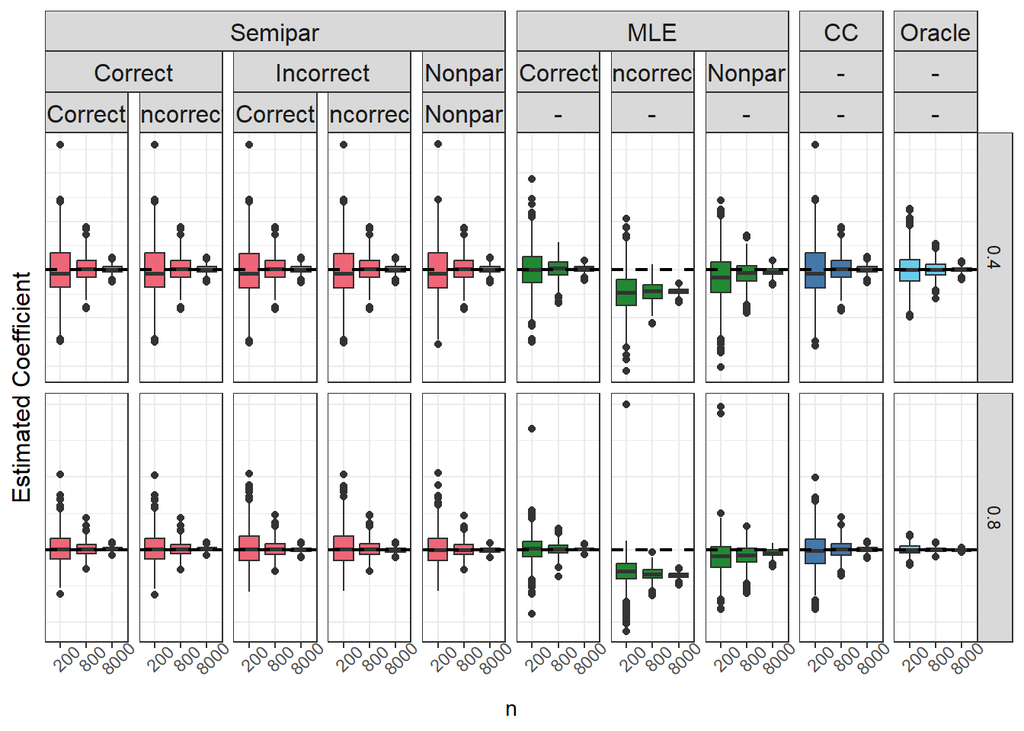

```r
pal_light <- c('#EE6677', '#228833', '#4477AA', '#CCBB44',
               '#66CCEE','#AA3377', '#BBBBBB')
font.size <- 12

sim.out.long %>%
  filter(param == 2) %>%
  mutate(n = factor(n)) %>%
  ggplot(aes(y = B,
             x = n,
             fill = method)) +
  geom_boxplot() +
  geom_hline(aes(yintercept = B.true),
             linetype = "dashed",
             linewidth = 0.75) +
  facet_nested(q ~ method + nuis.x + nuis.c,
               scales = "free") +
  theme_bw() +
  theme(axis.text.x = element_text(angle = 45),
        axis.ticks.y = element_blank(),
        axis.text.y = element_blank(),
        axis.title.y = element_text(size = font.size),
        strip.text.x = element_text(size = font.size)) +
  labs(y = "Estimated Coefficient") +
  guides(fill = "none", color = "none") +
  scale_fill_manual(values = pal_light[c(1, 2, 3, 5)])
```

#### Plot of Computation Times

```r
sim.out.time <- sim.out %>%
  select(n, q, starts_with("time")) %>%
  pivot_longer(starts_with("time"),
               names_to = "proc",
               values_to = "time") %>%
  mutate(proc = gsub("time.", "", proc)) %>%
  separate(proc, into = c("proc1", "proc2"), sep = "[.]") %>%
  mutate(Proc1 = factor(proc1,
                        levels = c("xz", "cz", "est", "var"),
                        labels = c("X|Z Model", "C|Z Model",
                                   "Parameter Estimation",
                                   "Variance Estimation"),
                        ordered = T),
         Proc2 = factor(proc2,
                        levels = c("sp", "ml", "cc", "or",
                                   "param", "nonpar"),
                        labels = c("SPARCC", "MLE",
                                   "Complete Case", "Oracle",
                                   "Parametric", "Nonparametric"),
                        ordered = T))
```

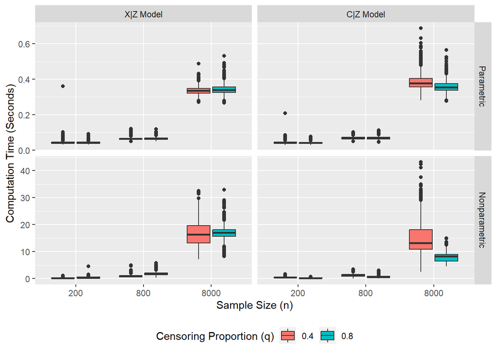

```r
# plot times for nuisance model fitting
sim.out.time %>%
  filter(proc1 %in% c("cz", "xz")) %>%
  mutate(n = factor(n),
         q = factor(q)) %>%
  ggplot(aes(x = n,
             y = time)) +
  geom_boxplot(aes(fill = q)) +
  facet_grid(Proc2 ~ Proc1,
             scales = "free") +
  labs(x = "Sample Size (n)",
       y = "Computation Time (Seconds)",
       fill = "Censoring Proportion (q)") +
  theme(legend.position = "bottom")
```

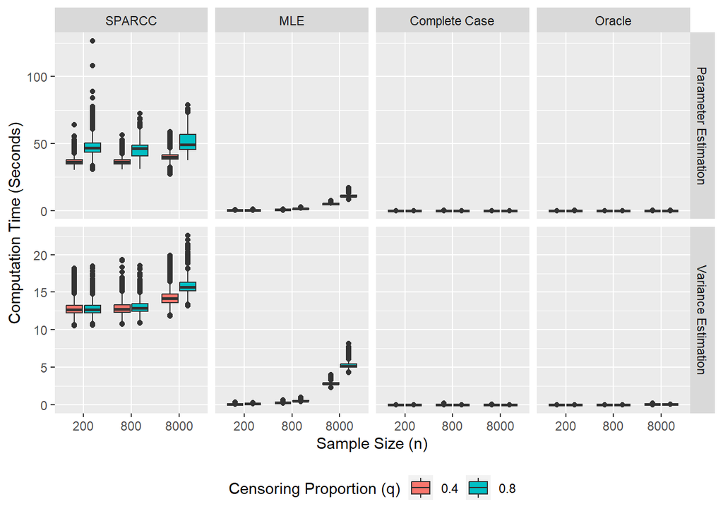

```r
# plot times for outcome model fitting
sim.out.time %>%
  filter(proc1 %in% c("est", "var")) %>%
  mutate(n = factor(n),
         q = factor(q)) %>%
  ggplot(aes(x = n,
             y = time)) +
  geom_boxplot(aes(fill = q)) +
  facet_grid(Proc1 ~ Proc2,
             scales = "free") +
  labs(x = "Sample Size (n)",
       y = "Computation Time (Seconds)",
       fill = "Censoring Proportion (q)") +
  theme(legend.position = "bottom")
```

#### Table of Computation Times

```r
tbl6 <- sim.out.time %>%
  filter(#proc1 %in% c("est", "var"),
         !is.na(time)) %>%
  group_by(n, q, Proc1, Proc2) %>%
  summarise(mean = mean(time),
            sd = sd(time)) %>%
  mutate(time = paste0(round(mean, 1), " (", round(sd, 2), ")")) %>%
  select(n, q, Proc1, Proc2, mean) %>%
  gather(key, value, mean) %>%
  unite(Group, n, q, key) %>%
  spread(Group, value)

tbl6
```

```
## # A tibble: 12 × 8
## # Groups:   Proc1 [4]
##    Proc1       Proc2 `200_0.4_mean` `200_0.8_mean` `800_0.4_mean` `800_0.8_mean`
##    <ord>       <ord>          <dbl>          <dbl>          <dbl>          <dbl>
##  1 X|Z Model   Para…        0.0433         0.0429         0.0647         0.0660
##  2 X|Z Model   Nonp…        0.312          0.454          0.945          1.85
##  3 C|Z Model   Para…        0.0436         0.0418         0.0683         0.0683
##  4 C|Z Model   Nonp…        0.506          0.229          1.28           0.762
##  5 Parameter … SPAR…       36.5           47.4           36.4           45.7
##  6 Parameter … MLE          0.148          0.373          0.530          1.27
##  7 Parameter … Comp…        0.00220        0.00237        0.00265        0.00226
##  8 Parameter … Orac…        0.00288        0.00370        0.00399        0.00445
##  9 Variance E… SPAR…       12.7           12.7           12.8           13.0
## 10 Variance E… MLE          0.0809         0.140          0.291          0.531
## 11 Variance E… Comp…        0.00164        0.00110        0.00422        0.00188
## 12 Variance E… Orac…        0.00230        0.00222        0.00588        0.00600
## # ℹ 2 more variables: `8000_0.4_mean` <dbl>, `8000_0.8_mean` <dbl>
```

```r
kbl6 <- setNames(tbl5, c("Task", "Method",
                 sub(".*_(.+?)_.*", "\\1", tail(names(tbl6), -2)))) %>%
  kable(digits = c(0, 0,
                   rep(1, 6)),
        format = "latex",
        align = "ccrrrrrr",
        booktabs = T) %>%
  kable_styling("striped") %>%
  row_spec(row = 0, bold = TRUE) %>%
  add_header_above(c(" " = 2,
                   "n = 200" = 2,
                   "n = 800" = 2,
                   "n = 8000" = 2))
```